# An analysis on feminine vernacular in 21st century American music

Michael Waldron

## Introduction

WARNING: THIS PROJECT FOCUSES ON AND CONTAINS EXPLICIT LANGUAGE, READER DISCRETION IS ADVISED

I made this project to study word choice when referring to women in song lyrics. Specifically, I wanted to see how those word choices differ between musical genres and over time. While my analysis won’t go too in-depth (at least for now) one sub-goal of this project is to illustrate how prevalent misogynistic language is in music today. I intend to compare the use of such harsh language to more acceptable phrases.

One important caveat is this analysis will be on the frequency of words that are traditionally feminine and/or used in reference to women. Meaning, I have not implemented any sort of algorithm to detect whether saying “bitch” in a song has been directed towards a man or a woman. Each instance of “bitch” will be counted, because culturally, if an individual calls a man a “bitch” it is intended to emasculate that man, thus conveying the same message as using the insult against a woman: being feminine makes you weak/lesser.

As I collect the word frequency data, I will include terms that are gender neutral such as “babe” and “baby”. Since many of the songs are written by female artists, one can assume many instances of gender neutral terms will be in reference to men. Therefore, all my analyses will be two-fold: with and without gender neutral terms.

### Loading libraries

```r
library(tidyverse)
library(reshape2)
library(evaluate)
```

## Getting and cleaning the data

The lyric data we will be using can be found at https://www.kaggle.com/gyani95/380000-lyrics-from-metrolyrics/data. It is a repository of approximately 380,000 songs and their lyrics distinguished by title, year, artist, and genre.

After loading the .csv, the data frame needs to be cleaned up a bit. I got rid of all the songs before the year 2000 as I want to focus on 21st century music. I then converted all text to lowercase so future pattern matching would be easier. To improve readability I replaced all ‘-’ with a space in the song and artist columns. Then, I removed all carriage return characters as these aren’t part of the songs, but from the lyric website itself. I also removed all songs without lyrics and/or valid genres as they won’t be very helpful. Finally, I removed all punctuation characters to once again make pattern matching easier.

```r
lyrics_raw <- read_csv("C:/Users/Michael/OneDrive/Professional/Projects/Women in Music/lyrics.csv", col_types = list(col_integer(), col_character(), col_integer(), col_character(), col_character(), col_character()))
```

```r
lyrics_readable <- lyrics_raw[,-1] %>%
  filter(year >= 2000) %>%
  mutate_at(c("song", "artist", "genre", "lyrics"), funs(tolower(.))) %>%
  mutate_at(c("song", "artist"), funs(gsub("-", " ", .))) %>%
  mutate_at(c("lyrics"), funs(gsub("\n", " ", .)))

unique(lyrics_readable$genre)
```

```
##  [1] "pop"           "hip-hop"       "not available" "other"
##  [5] "rock"          "metal"         "country"       "jazz"
##  [9] "electronic"    "folk"          "r&b"           "indie"
```

```r
lyrics_improved <- lyrics_readable %>%
  filter(genre != "other") %>%
  filter(genre != "not available") %>%
  drop_na()
```

```r
lyrics_df <- lyrics_improved %>%
  mutate_at(c("lyrics"), funs(gsub("[[:punct:]]","",.)))
```

```r
head(lyrics_df, n = 1)
```

```
## # A tibble: 1 x 5
##   song       year artist          genre lyrics
##   <chr>     <int> <chr>           <chr> <chr>
## 1 ego remix  2009 beyonce knowles pop   oh baby how you doing you know im~
```

## Recording frequencies

Once the lyrics data frame is clean, we need to get our actual frequency data. It is important to note that because the data set is so large I will not be including song title and artist name in any of my analyses.

```r
#Proof of concept

year <- lyrics_df$year[1]
genre <- lyrics_df$genre[1]

song <-lyrics_df$lyrics[1]
s_vector <- strsplit(song, " ")[[1]]

baby = 0
bitch = 0
chick = 0
cunt = 0
darling = 0
female = 0
girl = 0
honey = 0
lady = 0
sister = 0
shawty = 0
slut = 0
sweetheart = 0
whore = 0
woman = 0

for(word in s_vector){
  switch (word,
    "baby" = (baby = baby + 1),
    "babe" = (baby = baby + 1),
    "babes" = (baby = baby + 1),
    "bitch" = (bitch = bitch + 1),
    "bitches" = (bitch = bitch + 1),
    "chick" = (chick = chick + 1),
    "chicks" = (chick = chick + 1),
    "cunt" = (cunt = cunt + 1),
    "cunts" = (cunt = cunt + 1),
    "darling" = (darling = darling + 1),
    "darlings" = (darling = darling + 1),
    "darlin" = (darling = darling + 1),
    "darlings" = (darling = darling + 1),
    "female" = (female = female + 1),
    "females" = (female = female + 1),
    "girl" = (girl = girl + 1),
    "girls" = (girl = girl + 1),
    "gurl" = (girl = girl + 1),
    "gurls" = (girl = girl + 1),
    "gal" = (girl = girl + 1),
    "gals" = (girl = girl + 1),
    "honey" = (honey = honey + 1),
    "honies" = (honey = honey + 1),
    "lady" = (lady = lady + 1),
    "ladies" = (lady = lady + 1),
    "sister" = (sister = sister + 1),
    "sisters" = (sister = sister + 1),
    "sista" = (sister = sister + 1),
    "sistas" = (sister = sister + 1),
    "shawty" = (shawty = shawty + 1),
    "shawties" = (shawty = shawty + 1),
    "slut" = (slut = slut + 1),
    "sluts" = (slut = slut + 1),
    "sweetheart" = (sweetheart = sweetheart + 1),
    "sweethearts" = (sweetheart = sweetheart + 1),
    "sweety" = (sweetheart = sweetheart + 1),
    "sweetie" = (sweetheart = sweetheart + 1),
    "sweeties" = (sweetheart = sweetheart + 1),
    "whore" = (whore = whore + 1),
    "whores" = (whore = whore + 1),
    "hoe" = (whore = whore + 1),
    "hoes" = (whore = whore + 1),
    "thot" = (whore = whore + 1),
    "thots" = (whore = whore + 1),
    "woman" = (woman = woman + 1),
    "women" = (woman = woman + 1)
  )
}

words_df <- data.frame(year, genre, baby, bitch, chick, cunt, darling, female, girl, honey, lady, sister, shawty, slut, sweetheart, whore, woman, stringsAsFactors = FALSE)
words_df
```

```
##   year genre baby bitch chick cunt darling female girl honey lady sister
## 1 2009   pop    2     1     0    0       0      0    0     0    0      0
##   shawty slut sweetheart whore woman
## 1      0    0          0     0     1
```

Because the following code takes over an hour to execute, I ran it once and saved the results to a separate file. That file is what I will use for the analyses, but I will leave the code here (commented out) for reference.

```r
#Completing the work
#
#for(x in 2:nrow(lyrics_df)){
#  year <- lyrics_df$year[x]
#  genre <- lyrics_df$genre[x]
#
#  song <-lyrics_df$lyrics[x]
#  s_vector <- strsplit(song, " ")[[1]]
#
#  baby = 0
#  bitch = 0
#  chick = 0
#  cunt = 0
#  darling = 0
#  female = 0
#  girl = 0
#  honey = 0
#  lady = 0
#  sister = 0
#  shawty = 0
#  slut = 0
#  sweetheart = 0
#  whore = 0
#  woman = 0
#
#  for(word in s_vector){
#    switch (word,
#    "baby" = (baby = baby + 1),
#    "babe" = (baby = baby + 1),
#    "babes" = (baby = baby + 1),
#    "bitch" = (bitch = bitch + 1),
#    "bitches" = (bitch = bitch + 1),
#    "chick" = (chick = chick + 1),
#    "chicks" = (chick = chick + 1),
#    "cunt" = (cunt = cunt + 1),
#    "cunts" = (cunt = cunt + 1),
#    "darling" = (darling = darling + 1),
#    "darlings" = (darling = darling + 1),
#    "darlin" = (darling = darling + 1),
#    "darlings" = (darling = darling + 1),
#    "female" = (female = female + 1),
#    "females" = (female = female + 1),
#    "girl" = (girl = girl + 1),
#    "girls" = (girl = girl + 1),
#    "gurl" = (girl = girl + 1),
#    "gurls" = (girl = girl + 1),
#    "gal" = (girl = girl + 1),
#    "gals" = (girl = girl + 1),
#    "honey" = (honey = honey + 1),
#    "honies" = (honey = honey + 1),
#    "lady" = (lady = lady + 1),
#    "ladies" = (lady = lady + 1),
#    "sister" = (sister = sister + 1),
#    "sisters" = (sister = sister + 1),
#    "sista" = (sister = sister + 1),
#    "sistas" = (sister = sister + 1),
#    "shawty" = (shawty = shawty + 1),
#    "shawties" = (shawty = shawty + 1),
#    "slut" = (slut = slut + 1),
#    "sluts" = (slut = slut + 1),
#    "sweetheart" = (sweetheart = sweetheart + 1),
#    "sweethearts" = (sweetheart = sweetheart + 1),
#    "sweety" = (sweetheart = sweetheart + 1),
#    "sweetie" = (sweetheart = sweetheart + 1),
#    "sweeties" = (sweetheart = sweetheart + 1),
#    "whore" = (whore = whore + 1),
#    "whores" = (whore = whore + 1),
#    "hoe" = (whore = whore + 1),
#    "hoes" = (whore = whore + 1),
#    "thot" = (whore = whore + 1),
#    "thots" = (whore = whore + 1),
#    "woman" = (woman = woman + 1),
#    "women" = (woman = woman + 1)
#  )
#  }
#
#  words_df <- rbind(words_df, list(year, genre, baby, bitch, chick, cunt, darling, female, girl, honey, lady, sister, shawty, slut, sweetheart, whore, woman))
#}
```

```r
#write.csv(words_df, file = "word_data.csv", row.names=FALSE)
```

Now that we have written our observations we need to group the data by year and genre so it makes actual sense. Also, I’m sick of looking at some of these words so I’m going to blank them out - I think we all get the point by now.

```r
counts_raw <- read_csv("C:/Users/Michael/OneDrive/Professional/Projects/Women in Music/word_data.csv", col_types = list(col_integer(), col_character(), col_integer(), col_integer(), col_integer(), col_integer(), col_integer(), col_integer(), col_integer(), col_integer(), col_integer(), col_integer(), col_integer(), col_integer(), col_integer(), col_integer()))

counts_sum <- counts_raw %>%
  group_by(year, genre) %>%
  summarize(baby = sum(baby), b___h = sum(bitch), chick = sum(chick), c__t = sum(cunt), darling = sum(darling), female = sum(female), girl = sum(girl), honey = sum(honey), lady = sum(lady), sister = sum(sister), shawty = sum(shawty), s__t = sum(slut), sweetheart = sum(sweetheart), w___e = sum(whore), woman = sum(woman))

head(counts_sum, n = 19)
```

```
## # A tibble: 19 x 17
## # Groups:   year [2]
##     year genre     baby b___h chick  c__t darling female  girl honey  lady
##    <int> <chr>    <int> <int> <int> <int>   <int>  <int> <int> <int> <int>
##  1  2000 country     15     0     1     0       0      0     8     0     0
##  2  2000 electro~    90     1     0     0       1      0     7     0     0
##  3  2000 hip-hop    168   166     5     0       0      0    62     3    13
##  4  2000 indie        0     0     0     0       0      0     0     0     0
##  5  2000 jazz        43     0     0     0       2      0     7     9    14
##  6  2000 metal      186     0     0     0       1      0    31     3    17
##  7  2000 pop         77     0     0     0       8      0    39    19     1
##  8  2000 r&b         79     0     0     1       4      0    75     1     3
##  9  2000 rock       215    54     0     5       6      2   143    32    26
## 10  2001 country     36     0     0     0       4      0    29     3     5
## 11  2001 electro~     8     8     0     0       0      0     3     0     4
## 12  2001 folk         0     0     0     0       0      0     9     0     0
## 13  2001 hip-hop     85    60     4     0       1      1    56     2    16
## 14  2001 indie        0     0     0     0       0      0     0     0     0
## 15  2001 jazz        27     0     0     0       6      0     6    19     0
## 16  2001 metal       33     0     0     0       0      1    26     2     2
## 17  2001 pop        343     0     2     0      32      3   193    32    20
## 18  2001 r&b         68     2     0     0       8      0    38     7    13
## 19  2001 rock       260     2     2     0      14      0    55    29    10
## # ... with 6 more variables: sister <int>, shawty <dbl>, s__t <int>,
## #   sweetheart <int>, w___e <int>, woman <int>
```

Finally, to make the data frame work with ggplot we need to rearrange the data so there are word, year, genre, and frequency columns. Now each word can be treated as a variable of the same entity.

```r
counts_tidy <- counts_sum %>%
  gather(word, frequency, -year, -genre)

head(counts_tidy, n=19)
```

```
## # A tibble: 19 x 4
## # Groups:   year [2]
##     year genre      word  frequency
##    <int> <chr>      <chr>     <dbl>
##  1  2000 country    baby      15.0
##  2  2000 electronic baby      90.0
##  3  2000 hip-hop    baby     168
##  4  2000 indie      baby       0
##  5  2000 jazz       baby      43.0
##  6  2000 metal      baby     186
##  7  2000 pop        baby      77.0
##  8  2000 r&b        baby      79.0
##  9  2000 rock       baby     215
## 10  2001 country    baby      36.0
## 11  2001 electronic baby       8.00
## 12  2001 folk       baby       0
## 13  2001 hip-hop    baby      85.0
## 14  2001 indie      baby       0
## 15  2001 jazz       baby      27.0
## 16  2001 metal      baby      33.0
## 17  2001 pop        baby     343
## 18  2001 r&b        baby      68.0
## 19  2001 rock       baby     260
```

## Exploratory data analysis

Now that the collection process is complete, let’s see what the data can tell us. Also, because the data collection is skewed (not the same number of songs per genre nor per year), we will need to observe percentages of total phrases observed as opposed to raw frequency.

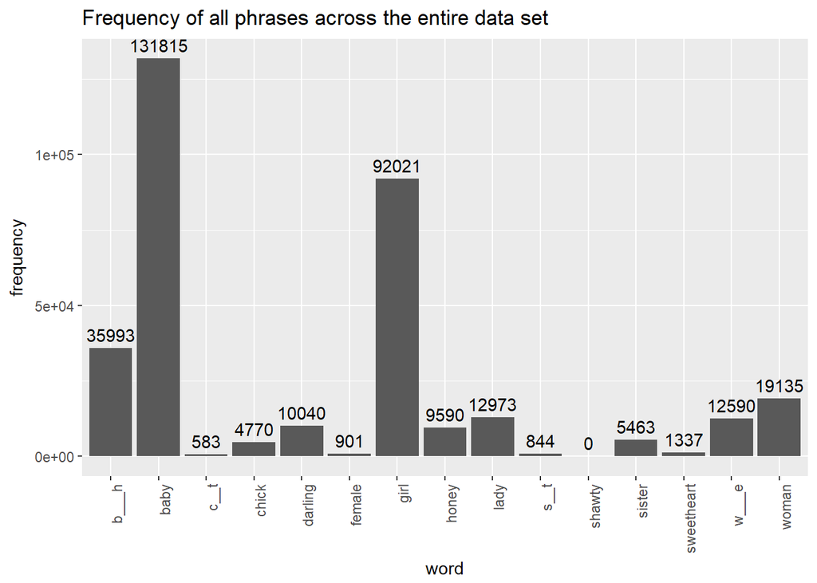

```r
counts_tidy %>%
  group_by(word) %>%
  summarize(frequency = sum(frequency)) %>%
  ggplot(aes(x = word, y = frequency)) +
  geom_bar(stat="identity") +
  geom_text(aes(x = word, y = frequency, label = frequency, vjust = -0.5)) +
  ggtitle("Frequency of all phrases across the entire data set") +
  theme(axis.text.x = element_text(angle = 90, hjust = 1))
```

```r
gendered_df <- counts_tidy %>%
  filter(word != "shawty") %>%
  filter(word != "baby") %>%
  filter(word != "darling") %>%
  filter(word != "honey") %>%
  filter(word != "sweetheart") %>%
  group_by(genre) %>%
  mutate(genre_total = sum(frequency))

gendered_df <- gendered_df %>%
  group_by(year) %>%
  mutate(year_total = sum(frequency))

gendered_df <- gendered_df %>%
  group_by(year, genre) %>%
  mutate(year_genre_total = sum(frequency))

neutral_df <- counts_tidy %>%
  filter(word != "shawty") %>%
  group_by(genre) %>%
  mutate(genre_total = sum(frequency))

neutral_df <- neutral_df %>%
  group_by(year) %>%
  mutate(year_total = sum(frequency))

neutral_df <- neutral_df %>%
  group_by(year, genre) %>%
  mutate(year_genre_total = sum(frequency))

head(gendered_df, n = 9)
```

```
## # A tibble: 9 x 7
## # Groups:   year, genre [9]
##    year genre      word  frequency genre_total year_total year_genre_total
##   <int> <chr>      <chr>     <dbl>       <dbl>      <dbl>            <dbl>
## 1  2000 country    b___h      0           6971        882            18.0
## 2  2000 electronic b___h      1.00        4550        882             8.00
## 3  2000 hip-hop    b___h    166          81463        882           363
## 4  2000 indie      b___h      0           1339        882             0
## 5  2000 jazz       b___h      0           3469        882            21.0
## 6  2000 metal      b___h      0           4444        882            52.0
## 7  2000 pop        b___h      0          33163        882            53.0
## 8  2000 r&b        b___h      0           3260        882            82.0
## 9  2000 rock       b___h     54.0        45946        882           285
```

```r
head(neutral_df, n = 9)
```

```
## # A tibble: 9 x 7
## # Groups:   year, genre [9]
##    year genre      word  frequency genre_total year_total year_genre_total
##   <int> <chr>      <chr>     <dbl>       <dbl>      <dbl>            <dbl>
## 1  2000 country    baby       15.0       15841       1854             34.0
## 2  2000 electronic baby       90.0        9088       1854             99.0
## 3  2000 hip-hop    baby      168        108371       1854            534
## 4  2000 indie      baby        0          2447       1854              0
## 5  2000 jazz       baby       43.0        9475       1854             78.0
## 6  2000 metal      baby      186          6366       1854            242
## 7  2000 pop        baby       77.0       78922       1854            157
## 8  2000 r&b        baby       79.0        8847       1854            166
## 9  2000 rock       baby      215         97431       1854            544
```

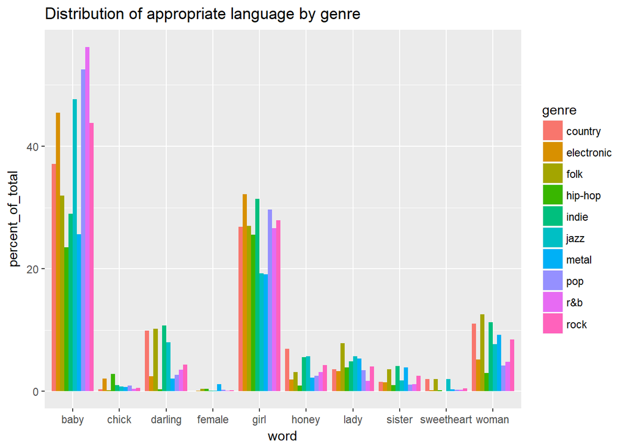

```r
neutral_df %>%
  group_by(word, genre, genre_total) %>%
  summarize(frequency = sum(frequency)) %>%
  mutate(percent_of_total = 100*(frequency/genre_total)) %>%
  filter(word != "b___h") %>%
  filter(word != "c__t") %>%
  filter(word != "s__t") %>%
  filter(word != "shawty") %>%
  filter(word != "w___e") %>%
  ggplot(aes(x = word, y = percent_of_total, fill = genre)) +
  geom_bar(stat="identity", position = "dodge") +
  ggtitle("Distribution of appropriate language by genre")
```

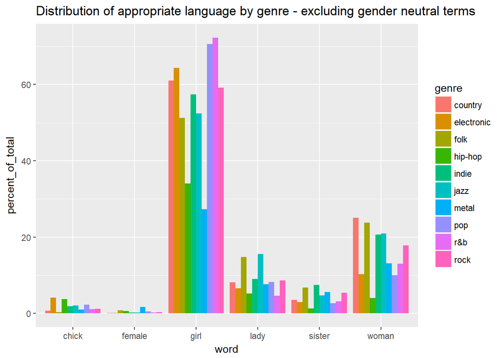

```r
gendered_df %>%
  group_by(word, genre, genre_total) %>%
  summarize(frequency = sum(frequency)) %>%
  mutate(percent_of_total = 100*(frequency/genre_total)) %>%
  filter(word != "b___h") %>%
  filter(word != "c__t") %>%
  filter(word != "s__t") %>%
  filter(word != "shawty") %>%
  filter(word != "w___e") %>%
  ggplot(aes(x = word, y = percent_of_total, fill = genre)) +
  geom_bar(stat="identity", position = "dodge") +
  ggtitle("Distribution of appropriate language by genre - excluding gender neutral terms")
```

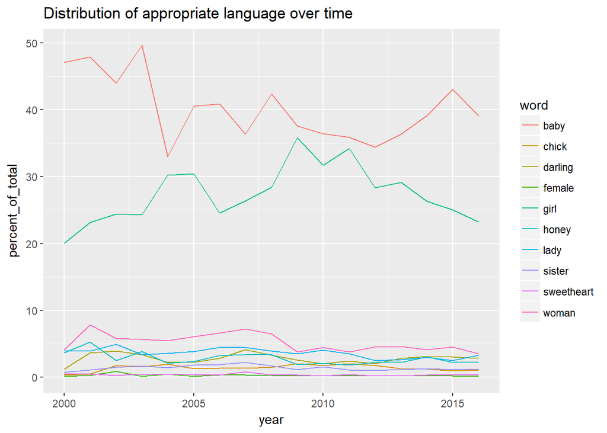

```r
neutral_df %>%
  group_by(word, year, year_total) %>%
  summarize(frequency = sum(frequency)) %>%
  mutate(percent_of_total = 100*(frequency/year_total)) %>%
  filter(word != "b___h") %>%
  filter(word != "c__t") %>%
  filter(word != "s__t") %>%
  filter(word != "shawty") %>%
  filter(word != "w___e") %>%
  ggplot(aes(x = year, y = percent_of_total, color = word)) +
  geom_line() +
  ggtitle("Distribution of appropriate language over time")
```

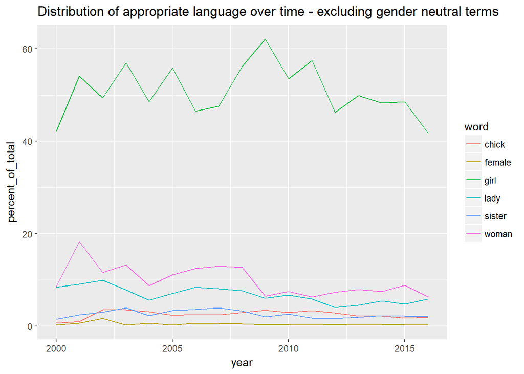

```r
gendered_df %>%
  group_by(word, year, year_total) %>%
  summarize(frequency = sum(frequency)) %>%
  mutate(percent_of_total = 100*(frequency/year_total)) %>%
  filter(word != "b___h") %>%
  filter(word != "c__t") %>%
  filter(word != "s__t") %>%
  filter(word != "shawty") %>%
  filter(word != "w___e") %>%
  ggplot(aes(x = year, y = percent_of_total, color = word)) +
  geom_line() +
  ggtitle("Distribution of appropriate language over time - excluding gender neutral terms")
```

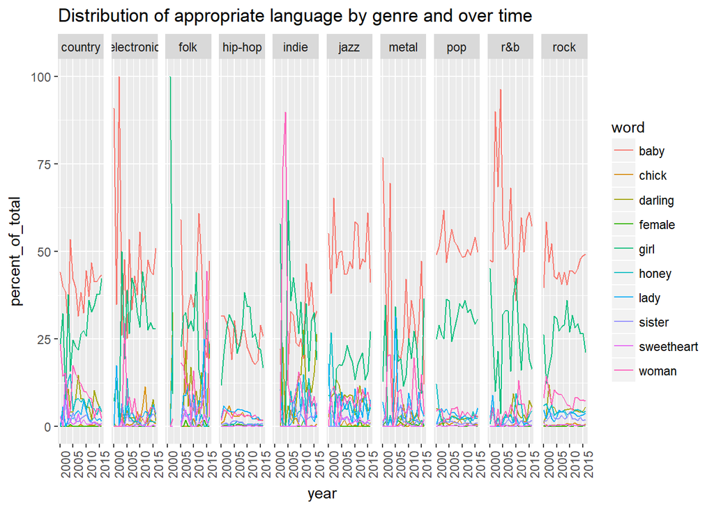

```r
neutral_df %>%
  group_by(word, year, genre, year_genre_total) %>%
  summarize(frequency = sum(frequency)) %>%
  mutate(percent_of_total = 100*(frequency/year_genre_total)) %>%
  filter(word != "b___h") %>%
  filter(word != "c__t") %>%
  filter(word != "s__t") %>%
  filter(word != "shawty") %>%
  filter(word != "w___e") %>%
  ggplot(aes(x = year, y = percent_of_total, color = word)) +
  geom_line() +
  facet_grid(~genre) +
  ggtitle("Distribution of appropriate language by genre and over time") +
  theme(axis.text.x = element_text(angle = 90, hjust = 1))
```

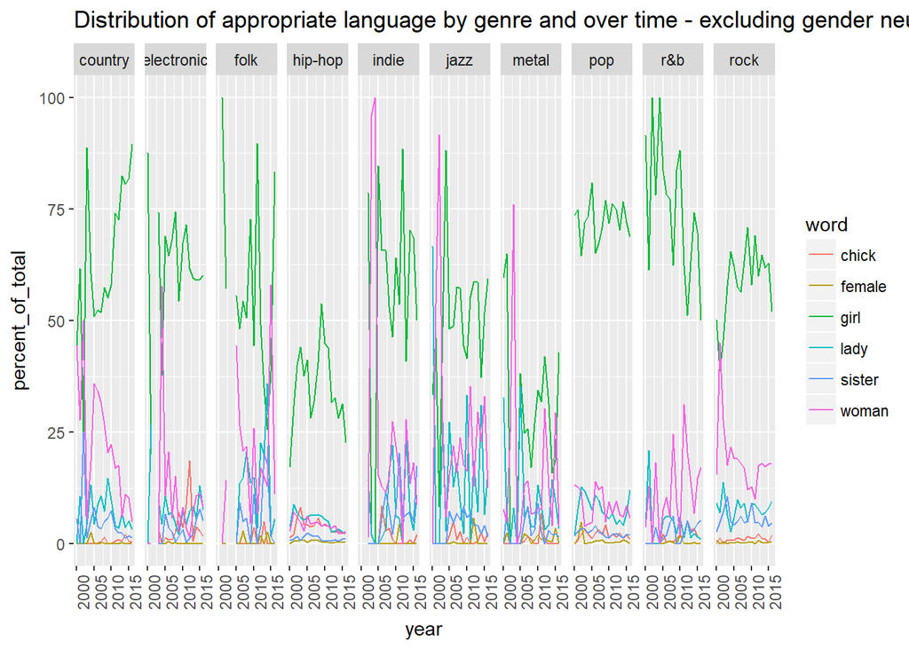

```r
gendered_df %>%
  group_by(word, year, genre, year_genre_total) %>%
  summarize(frequency = sum(frequency)) %>%
  mutate(percent_of_total = 100*(frequency/year_genre_total)) %>%
  filter(word != "b___h") %>%
  filter(word != "c__t") %>%
  filter(word != "s__t") %>%
  filter(word != "shawty") %>%
  filter(word != "w___e") %>%
  ggplot(aes(x = year, y = percent_of_total, color = word)) +
  geom_line() +
  facet_grid(~genre) +
  ggtitle("Distribution of appropriate language by genre and over time - excluding gender neutral terms") +
  theme(axis.text.x = element_text(angle = 90, hjust = 1))
```

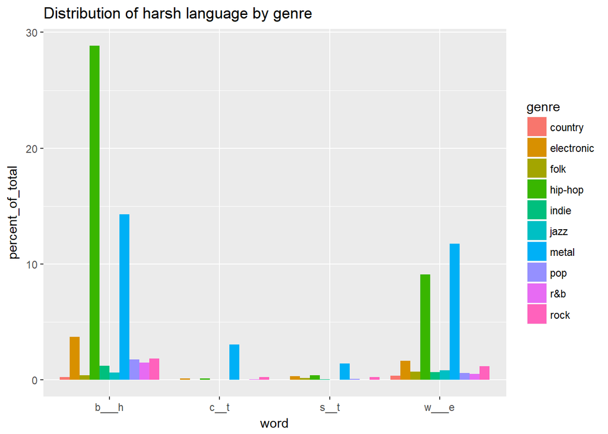

```r
neutral_df %>%
  group_by(genre, word, genre_total) %>%
  summarize(frequency = sum(frequency)) %>%
  mutate(percent_of_total = 100*(frequency/genre_total)) %>%
  filter(word != "baby") %>%
  filter(word != "chick") %>%
  filter(word != "darling") %>%
  filter(word != "female") %>%
  filter(word != "girl") %>%
  filter(word != "honey") %>%
  filter(word != "lady") %>%
  filter(word != "sister") %>%
  filter(word != "sweetheart") %>%
  filter(word != "woman") %>%
  ggplot(aes(x = word, y = percent_of_total, fill = genre)) +
  geom_bar(stat="identity", position = "dodge") +
  ggtitle("Distribution of harsh language by genre")
```

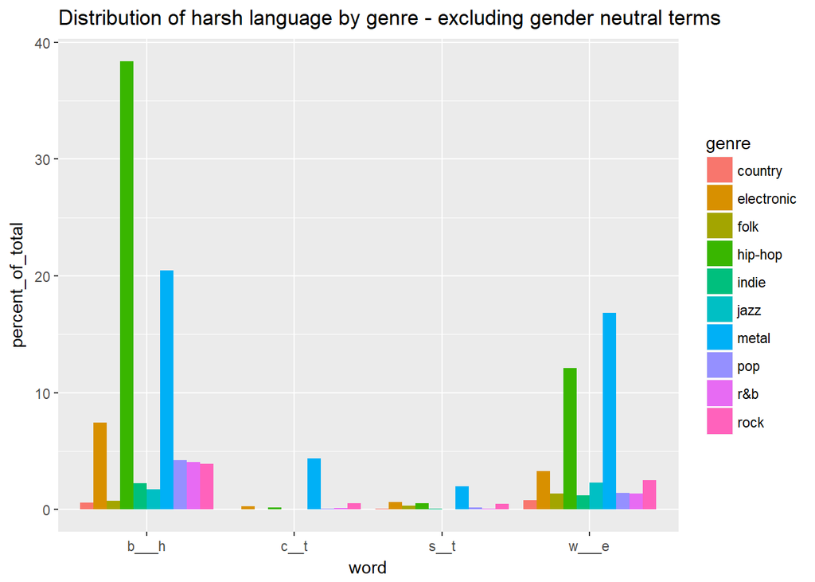

```r
gendered_df %>%
  group_by(genre, word, genre_total) %>%
  summarize(frequency = sum(frequency)) %>%
  mutate(percent_of_total = 100*(frequency/genre_total)) %>%
  filter(word != "chick") %>%
  filter(word != "female") %>%
  filter(word != "girl") %>%
  filter(word != "lady") %>%
  filter(word != "sister") %>%
  filter(word != "woman") %>%
  ggplot(aes(x = word, y = percent_of_total, fill = genre)) +
  geom_bar(stat="identity", position = "dodge") +
  ggtitle("Distribution of harsh language by genre - excluding gender neutral terms")
```

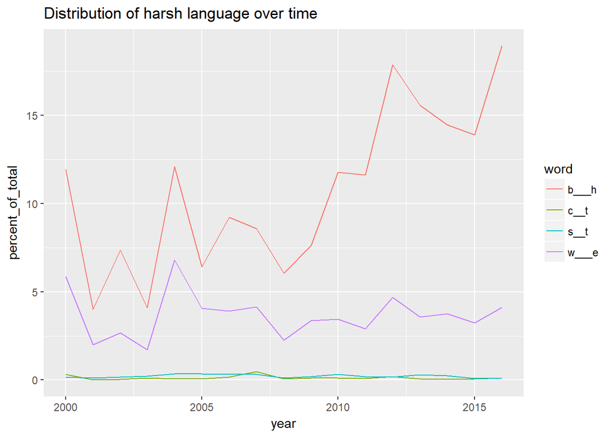

```r
neutral_df %>%
  group_by(word, year, year_total) %>%
  summarize(frequency = sum(frequency)) %>%
  mutate(percent_of_total = 100*(frequency/year_total)) %>%
  filter(word != "baby") %>%
  filter(word != "chick") %>%
  filter(word != "darling") %>%
  filter(word != "female") %>%
  filter(word != "girl") %>%
  filter(word != "honey") %>%
  filter(word != "lady") %>%
  filter(word != "sister") %>%
  filter(word != "sweetheart") %>%
  filter(word != "woman") %>%
  ggplot(aes(x = year, y = percent_of_total, color = word)) +
  geom_line() +
  ggtitle("Distribution of harsh language over time")
```

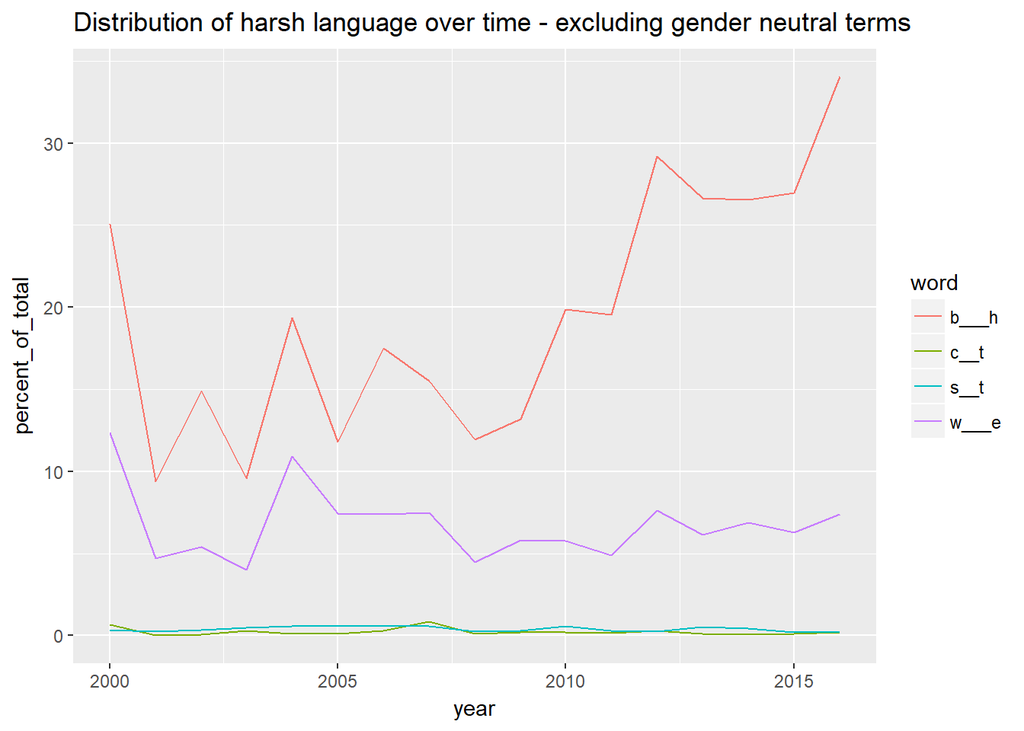

```r
gendered_df %>%
  group_by(word, year, year_total) %>%
  summarize(frequency = sum(frequency)) %>%
  mutate(percent_of_total = 100*(frequency/year_total)) %>%
  filter(word != "chick") %>%
  filter(word != "female") %>%
  filter(word != "girl") %>%
  filter(word != "lady") %>%
  filter(word != "sister") %>%
  filter(word != "woman") %>%
  ggplot(aes(x = year, y = percent_of_total, color = word)) +
  geom_line() +
  ggtitle("Distribution of harsh language over time - excluding gender neutral terms")
```

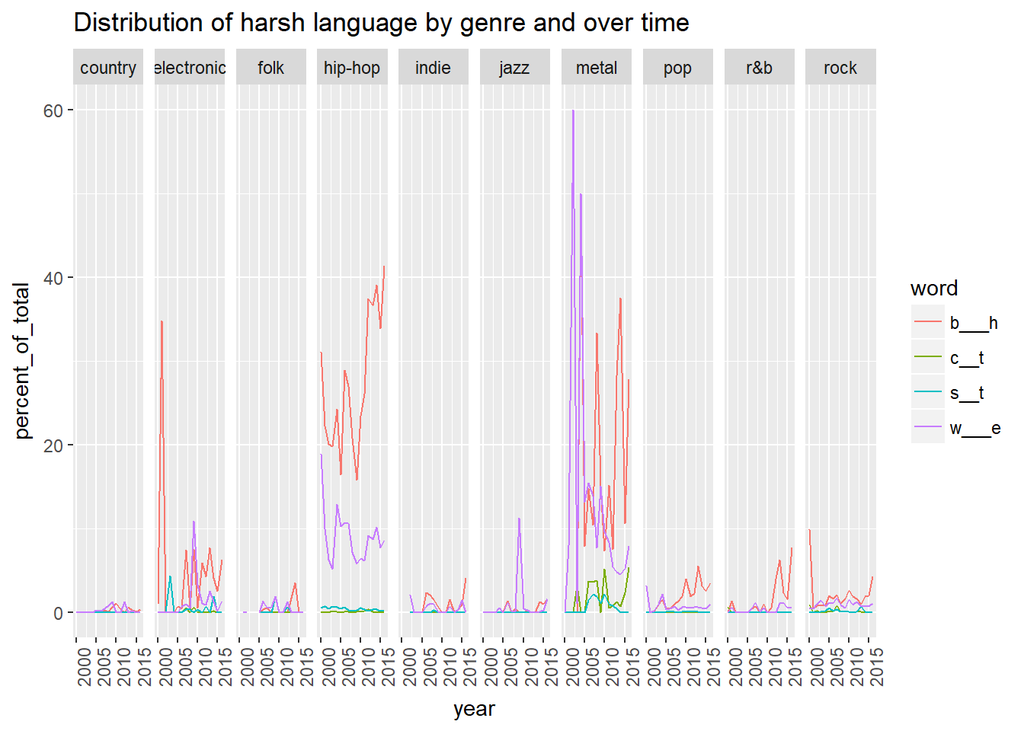

```r
neutral_df %>%
  group_by(word, year, genre, year_genre_total) %>%
  summarize(frequency = sum(frequency)) %>%
  mutate(percent_of_total = 100*(frequency/year_genre_total)) %>%
  filter(word != "baby") %>%
  filter(word != "chick") %>%
  filter(word != "darling") %>%
  filter(word != "female") %>%
  filter(word != "girl") %>%
  filter(word != "honey") %>%
  filter(word != "lady") %>%
  filter(word != "sister") %>%
  filter(word != "sweetheart") %>%
  filter(word != "woman") %>%
  ggplot(aes(x = year, y = percent_of_total, color = word)) +
  geom_line() +
  facet_grid(~genre) +
  ggtitle("Distribution of harsh language by genre and over time") +
  theme(axis.text.x = element_text(angle = 90, hjust = 1))
```

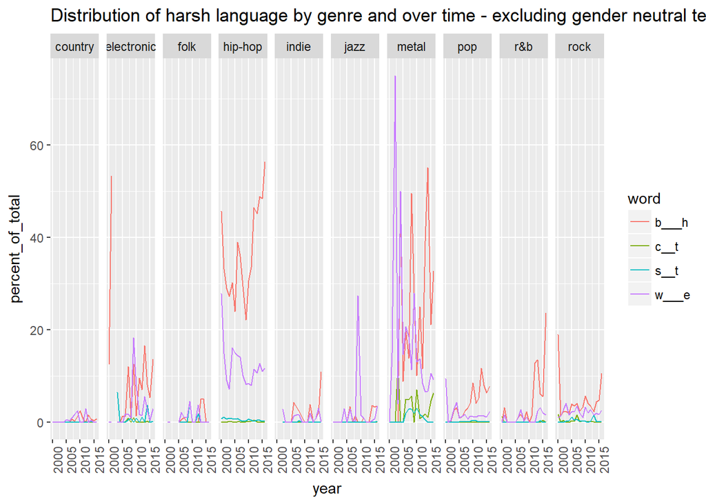

```r
gendered_df %>%
  group_by(word, year, genre, year_genre_total) %>%
  summarize(frequency = sum(frequency)) %>%
  mutate(percent_of_total = 100*(frequency/year_genre_total)) %>%
  filter(word != "chick") %>%
  filter(word != "female") %>%
  filter(word != "girl") %>%
  filter(word != "lady") %>%
  filter(word != "sister") %>%
  filter(word != "woman") %>%
  ggplot(aes(x = year, y = percent_of_total, color = word)) +
  geom_line() +
  facet_grid(~genre) +
  ggtitle("Distribution of harsh language by genre and over time - excluding gender neutral terms") +
  theme(axis.text.x = element_text(angle = 90, hjust = 1))
```

## Discussion

While I personally believe that nothing should be off limits for art, everything in art should have a purpose, especially if what is included is harsh, shocking, controversial, etc. It is safe to say that most of the instances of harsh language in these songs do not serve a purpose, do not convey a deeper meaning, but are weapons in one of two ways. The first is obvious: a direct insult intended to do harm by objectifying women, reducing women to animals, or (as previously stated) implying a man is lesser for acting like a woman. The second is both more common, and honestly much more dangerous: when words like “bitch” are simply used to replace “girl” or “woman” without any ulterior motive directly attached to the word. These replacements are worse because they are lazy writing that keep misogyny very much alive in American culture by normalizing hate speech.

We need to do a better job teaching boys to respect women. Not only this, but we need to teach them to give respect for the right reasons. Don’t tell boys they need to respect women because women are fragile and need protection. Don’t tell boys they need to respect women because “happy wife, happy life”. Tell boys to respect women, because women are people and therefore deserve your respect on a fundamental level. We also need female artists to step-up and fight against misogynistic language in music, both by refusing to participate themselves and refusing to work with artists who are a part of the problem.

I won’t sit here and type away as though I have all the answers, but what I do know is misogyny is perceived as so normal today that the President of the United States can say “moved on her like a bitch… grab them by the pussy” and not be held accountable. Not only was Trump not held accountable, but his campaign was able to convince millions of Amerians that his statements weren’t misogynistic, but simply “locker room talk” aka “boys being boys”. While I don’t know all the answers, I know we can and need to do better.

I’d like to end on a positive note, so I will share a short & simple phrase that has been lingering in my mind since I heard it a few weeks ago: “It’s chaos, be kind” (Patton Oswalt/Michelle McNamara).